# Election Project

Jessica Chen, Joon Seokjoon Lee, Roozbeh Faghihi Moghdam, Sue Ying Tay, Taejin Jeong

#### 2016 Presidential Election Debrief Project

### STEP 1. DATA WRANGLING

## 1. 2016 Presidential Election results reported at the country level.

reference: 1)http://www.stat.berkeley.edu/users/nolan/data/voteProject/2016_US_County_Le vel_Presidential_Results.csv 2)https://github.com/tonmcg/County_Level_Election_Results_1216/blob/master/2016_US_County_Level_Presidential_Results.csv package: XML, rgdal

```r
#Set working directory
setwd("~/Google Drive/workingdirectory")

library(XML)
library(rgdal)
library(readxl)


election.2016 = read.csv(file = "http://www.stat.berkeley.edu/users/nolan/data/voteProject/2016_US_County_Level_Presidential_Results.csv", header = TRUE) # read 2016 presidential election file
```

# REBUILDING ELECTION 2016

In Election 2016, the data of Alaska is inconsistent and ‘X’ column is needless, so we dismiss them. Since in Election 2004 and 2008 do not have any information about other parties except Democratic and Republican, we decide to change total_votes, which is total of all parties with other parites, to total of only two parties, Democratic and Republican. Then, we also need to change percentage, differentiation, and differentiation of percentage of votes for Democratic and Republican. Also, there are some counties which have ‘Parish’ and ‘city’ instead of ‘County’ in their names, so we change them to ‘County’. And, change factors of the dataframe to character strings to match with other files.

```r
election.2016 = election.2016[election.2016$state_abbr != "AK",] #The data of Alaska is inconsistent, so I dismiss it.

election.2016 = election.2016[, names(election.2016) != 'X'] # 'X' column is needless, so I dismiss it

election.2016$total_votes = election.2016$votes_dem+election.2016$votes_gop #In election 2004 and 2008 do not have any information about other parties, we decide to change total_votes, which is total of all parties with other parties, to total of only Democratic and Republican

election.2016$per_dem = election.2016$votes_dem/election.2016$total_votes #percentage of Democratic

election.2016$per_gop = election.2016$votes_gop/election.2016$total_votes #percentage of Republican

election.2016$diff = abs(election.2016$votes_dem - election.2016$votes_gop) #differentiation of Democratic and Republican

election.2016$per_point_diff = abs(election.2016$per_dem -
                                     election.2016$per_gop)
#differentiation of percentage of Democratic and Republican

election.2016 <- as.data.frame(sapply(election.2016,gsub,pattern="Parish",replacement="County")) #there are some counties which have Parish instead of County in their names, so change them to County

election.2016 <- as.data.frame(sapply(election.2016,gsub,pattern="city",replacement="County")) #there are some counties which have city instead of County in their names, so change them to County

election.2016 = data.frame(lapply(election.2016, as.character), stringsAsFactors=FALSE) #change factors to character strings
```

## 2. 2012 Presidential Election results reported at the country level.

Author: Joon Seokjoon Lee reference: 1)http://www.politico.com/2012-election/map/#/President/2012/ 2)http://www.stat.berkeley.edu/users/nolan/data/voteProject/countyVotes2012/xxx.xml 3)http://www.stat.berkeley.edu/users/nolan/data/voteProject/countyVotes2012/stateNames.txt 4)http://stackoverflow.com/questions/10644998/xml-to-r-data-extraction package: XML, rgdal, data.table

# READING ELECTION 2012 FILE AND REBUILDING STATES NAME FILE

I read states name file. Then, I removed white space of the states names to match with Election 2016. Also, I removed Alaska since it is inconsistent data. And, I made a list of URLs to store all URLs of states in xmlparse, then parsed XML file of states using sapply.

```r
states = read.table("http://www.stat.berkeley.edu/users/nolan/data/voteProject/countyVotes2012/stateNames.txt", sep = "\t") #read states name file

states = sub(" +", "", states$V1) #remove white space

states = states[states != "states" & states != "alaska"] #remove Alaska since it is inconsistent data

states_info = paste("http://www.stat.berkeley.edu/users/nolan/data/voteProject/countyVotes2012/",states,".xml", sep = "") #make list of URLs to store all URLs of states in xmlparse

states_doc = sapply(states_info, xmlParse) #parse XML file of states
```

# BUILDING ELECTION 2012

# GETTING NUMBER OF VOTES FOR EACH PARTY

First, I made two list of number of votes, one for Democratic and other for Republican for each state, from the XML file. Then, I removed ‘,’ from two lists to make them numeric and unlist to merge them to dataframe of Election 2012. Then, I made small dataframe for those number of votes for Democratic and Republican. From it, I got total votes of Democratic and Republican parties, and made dataframe those three things.

```r
votes_dem1 = list()
for(i in 1:50){
  votes_dem1[[i]] = xpathSApply(xmlRoot(states_doc[[i]]), '//tr[@class= "party-democrat race-winner" or @class = "party-democrat"]/td[@class = "results-popular"]', xmlValue)
} #make a list of number of votes for Democratic for each state
votes_dem = as.numeric(gsub(",","",unlist(votes_dem1))) #remove ',' to make it numeric and make it unlist to merge it to dataframe of 2012 election.

votes_gop1 = list()
for(i in 1:50){
  votes_gop1[[i]] = xpathSApply(xmlRoot(states_doc[[i]]), '//tr[@class= "party-republican race-winner" or @class = "party-republican"]/td[@class = "results-popular"]', xmlValue)
} #make a list of number of votes for Republican for each state
votes_gop = as.numeric(gsub(",","",unlist(votes_gop1))) #remove ',' to make it numeric and make it unlist to merge it to dataframe of 2012 election.

votes_data = data.frame(votes_dem, votes_gop,
                  stringsAsFactors = FALSE)       #make small dataframe for votes_dem and votes_gop.

total_votes = votes_data$votes_dem+votes_data$votes_gop #get total votes of Democratic and Republican parties

votes_data = data.frame(votes_data,total_votes, stringsAsFactors = FALSE) #merge votes_dem, votes_gop, and total_votes
```

# PERCENTAGE OF DEMOCRATIC AND REPUBLICAN // DIFFERENTIATION

I got percentage of votes, differentiation of votes, and differentiation of percentage of votes for Democratic and Republican.

```r
per_dem = votes_data$votes_dem/votes_data$total_votes #percentage of Democratic
per_gop = votes_data$votes_gop/votes_data$total_votes #percentage of Republican
diff = abs(votes_data$votes_dem - votes_data$votes_gop) #differentiation of Democratic and Republican
per_point_diff = abs(per_dem - per_gop) #differentiation of percentage of Democratic and Republican
```

# ABBREVIATION OF STATES FOR ELECTION 2012

I made abbreviation of states form Election 2016 to apply them to Election 2012, then made it unlist to merge to the dataframe of Election 2012.

```r
abbreviation_state = c("AL", "AZ", "AR", "CA", "CO", "CT", "DE", "DC", "FL", "GA", "HI","ID", "IL", "IN", "IA", "KS", "KY", "LA", "ME", "MD", "MA", "MI", "MN","MS", "MO",  "MT", "NE", "NV", "NH", "NJ", "NM", "NY", "NC", "ND", "OH","OK", "OR", "PA", "RI", "SC", "SD", "TN", "TX", "UT", "VT", "VA", "WA","WV", "WI", "WY") #make abbreviation of states from election 2016 to apply them to election 2012
state_abbr1 = list()
for(i in 1:50){
  state_abbr1[[i]] = rep(abbreviation_state[i],length(votes_dem1[[i]]))
}
state_abbr = unlist(state_abbr1) #make it unlist to merge to dataframe
```

# COUNTY NAME

I got names of counties from the XML file, and removed first row whose name is just ‘County’, an needless strings. Also, I inserted ‘county’ to end of all strings to make county_name same as Election 2016.

```r
county_name1 = list()
for(i in 1:50){
  county_name1[[i]] = xpathSApply(xmlRoot(states_doc[[i]]), '//th[@class = "results-county"]', xmlValue)
  county_name1[[i]] = county_name1[[i]][-1] #remove first row whose name is "County"
}

county_name = as.character(gsub(" \\d+\\.\\d% Reporting","",unlist(county_name1))) #remove needless strings and make them unlist and character to merge into dataframe.
county_name[county_name != "District of Columbia"] = paste0(county_name[county_name != "District of Columbia"],' County') #insert ' County' to end of all strings to make county_name same as the election 2016
```

# COUNTY ID

I got ID of counties from the XML file, and made a list of the attributes of ID to make combined_fips column. Then, I removed needless word from the ID and made it unlist and numeric to merge into the dataframe of Election 2012.

```r
combined_fips1 = list()
for(i in 1:50){
  combined_fips1[[i]] = xpathSApply(xmlRoot(states_doc[[i]]), '//tbody', xmlGetAttr, "id")
}  #make a list of attributes of id's of tbody to get combined_fips

combined_fips = as.numeric(gsub("county","",unlist(combined_fips1))) #remove needless word and make them unlist and numeric to merge into dataframe.
```

# MERGING

I merged all data for Election 2012 together and changed factors to character strings to match with other files. Then, I dropped all unused columns. Then, I merged Election 2012 and Election 2016 by combined_ips which is ID of counties since ID of counties are unique. So, we can keep all data of Election of 2012 and 2016 except Bedford City County which is not in Election 2016. We decided to ignore it since there is no data of Bedford City County in Election 2016. At the end, I renamed some column names with candidates’ names and election years to distinguish easily with other years.

```r
library(data.table)

election.2012 = cbind(votes_data, per_dem, per_gop, diff, per_point_diff, state_abbr, county_name, combined_fips) #merge all data of 2012 election
election.2012 = data.frame(lapply(election.2012, as.character), stringsAsFactors=FALSE) #change factors to character strings
election.2012 <- as.data.frame(sapply(election.2012,gsub,pattern="Saint",replacement="St.")) #there are some county which have Saint instead of St. in their names, so change them to St.
election.2012 <- as.data.frame(sapply(election.2012,gsub,pattern="County County",replacement="County")) #there are some county which have "County County" instead of "County" in their names, so change them to "County"

drops = c("state_abbr","county_name")
election.2012 = election.2012[, !(names(election.2012) %in% drops)]

election_2012_2016 = merge(election.2016, election.2012, by = c("combined_fips")) #merge election 2016 and 2012

setnames(election_2012_2016, old = c("votes_dem.x", "votes_gop.x", "total_votes.x", "per_dem.x", "per_gop.x", "diff.x", "per_point_diff.x", "votes_dem.y", "votes_gop.y", "total_votes.y", "per_dem.y", "per_gop.y", "diff.y", "per_point_diff.y"),
         new = c("Clinton_2016", "Trump_2016", "Total_2016", "DemProp_2016", "RepProp_2016", "DiffVotes_2016", "DiffPer_2016", "Obama_2012", "Romney_2012", "Total_2012", "DemProp_2012", "RepProp_2012", "DiffVotes_2012", "DiffPer_2012"))
```

## 3. 2008 Presidential Election results reported at the country level.

Author: Roozbeh Faghihi Moghdam / 25765752 reference: 1)http://www.stat.berkeley.edu/users/nolan/data/voteProject/countyVotes2008.xlsx 2)http://stackoverflow.com/questions/5411979/state-name-to-abbreviation-in-r 3)http://stackoverflow.com/questions/5487164/r-how-to-replace-parts-of-variable-strings-within-data-frame package: read

link for working directory: “https://drive.google.com/drive/folders/0B4YhhdRvxI4_TFd3ci1HcXRvRmc?usp=sharing”

First we need a package to read “xlsx” format, we downloaded “readxl” package for this purpose. We downloaded the file to working directory which is a public folder in google drive. After creating “result_2008” we need to clean the raw data. First, we dropped first sheet, which includes general data about election. Moreover, some of sheets had NULL column, which should be dropped. We also, dropped “Alaska” sheet, and changed column names to have same format as 2016 file. At the end we defined a column of total Obama and McCain votes, and created two new columns that are proportion of Democrat and Republican candidates: “DemProp” and “RepProp”.

```r
library(readxl)

#Download excel file from {http://www.stat.berkeley.edu/users/nolan/data/voteProject/countyVotes2008.xlsx} in your working directory

download.file("http://www.stat.berkeley.edu/users/nolan/data/voteProject/countyVotes2008.xlsx", destfile = "~/Google Drive/workingdirectory/countyVotes2008.xlsx")

#Reading Data
result_2008 <- sapply(excel_sheets("countyVotes2008.xlsx"), read_excel, path = "~/Google Drive/workingdirectory/countyVotes2008.xlsx")
```

## Cleaning Data

```r
#Drop first sheet
result_2008 <- result_2008[-1]

#Eliminate nulls
result_2008 <- result_2008[!sapply(result_2008, is.null)]

#Drop column of NAs
result_2008 <- lapply(result_2008, '[', -7)

#Change state name to short symbols
states_name <- state.abb[match(names(result_2008),state.name)]
result_2008 <- mapply(`[<-`, result_2008, 'State', value = states_name, SIMPLIFY = FALSE)

#Combine all excel sheets to one dataframe
result_2008 <- as.data.frame(do.call(rbind, result_2008))

#Change column names
colnames(result_2008) <- c("county_name", "Total Precincts", "Precincts Reporting", "Obama_2008", "McCain_2008", "Other", "state_abbr")

#Add "County" at the end of county names
result_2008$county_name <- paste0(result_2008$county_name, "County")

#Drop Alaska
result_2008 <- result_2008[!result_2008$state_abbr == "AK", ]
```

## Add more columns for data analysis

```r
#Sum of Democrats and Republicans votes

result_2008$Total_2008 <- result_2008$Obama_2008 + result_2008$McCain_2008

#Democrat and Republican Proportion
result_2008$DemProp_2008 <- result_2008$Obama/(result_2008$Obama + result_2008$McCain)
result_2008$RepProp_2008 <- 1 - result_2008$DemProp
result_2008$Diff_vote_2008 <- abs(result_2008$Obama - result_2008$McCain_2008)
result_2008$Diff_percent_2008 <- abs(result_2008$DemProp_2008 - result_2008$RepProp_2008)
```

# Drop unwanted columns

```r
result_2008$`Total Precincts` <-NULL
result_2008$`Precincts Reporting` <-NULL
result_2008$Other <-NULL
```

## Export CSV file

```r
#Export CSV file to working directory
write.csv(file = "~/Google Drive/workingdirectory/result2008.csv", x= result_2008)
```

At the end by using “write.csv” function, final dataframe for 2008 is saved at working directory. Notice that to run this chunk working directory must be defined.

## 4. 2004 Presidential Election results reported at the country level.

Author: Taejin Jeong reference: 1)http://www.stat.berkeley.edu/users/nolan/data/voteProject/countyVotes2004.txt package: XML, rgdal

# Reading txt file

load txt files using read.table function and name it a.

```r
library(XML)
library(rgdal)

a = read.table("http://www.stat.berkeley.edu/users/nolan/data/voteProject/countyVotes2004.txt")
```

# Modifying datas by column

Split the data(V1, V2, V3) seperately to work it by column and exclude the first row for it is name of columns. First, split states and counties to make informations to be easy to merge. And unlist the data to work with character vectors. After that, switch the state name by state abbreviations and add “County” at the end of the county name and make upper case for the first letter of county name.

```r
a = a[-1,]

b = sapply(a[[1]], function(x){
  strsplit(as.character(x), split = ",")
})

state_abbr = unlist(lapply(b, '[[' , 1))

state_abbr = state.abb[match(state_abbr,tolower(state.name))]

county_name = unlist(lapply(b, '[[' , 2))

county_name = paste0(county_name, " County")

d = function(x) {
  e = strsplit(x, " ")[[1]]
  paste(toupper(substring(e, 1,1)), substring(e, 2), sep="", collapse=" ")
}

county_name = sapply(county_name, function(x){
  d(x)
})
```

# Make more information by using datas for votes

To get information for votes using by Bush_2004 and Kerry_2004, convert the factor vector for votes into numeric vector. By subtracting, adding and dviding those values, get values for votes.

```r
Bush_2004 = as.numeric(levels(unlist(a[2]))[unlist(a[2])])

Kerry_2004 = as.numeric(levels(unlist(a[3]))[unlist(a[3])])

Diff_votes_2004 = abs(Bush_2004 - Kerry_2004)

Total_2004 = (Bush_2004 + Kerry_2004)

DemProp_2004 = (Kerry_2004 / Total_2004)

RepProp_2004 = (Bush_2004 / Total_2004)

Diff_percent_2004 = abs(RepProp_2004 - DemProp_2004)
```

# Combine all the datas into one

By using data.frame, combine the columns into one as a data frame

```r
v2004 = data.frame(Bush_2004, Kerry_2004, Total_2004, DemProp_2004, RepProp_2004, Diff_votes_2004, Diff_percent_2004, state_abbr, county_name)
```

## 5. Census data from the 2010 census

5. Census data from the 2010 census Author: Sue Ying Tay reference: http://www.stat.berkeley.edu/~nolan/data/voteProject/census2010/B01003.csv http://www.stat.berkeley.edu/~nolan/data/voteProject/census2010/DP02.csv http://www.stat.berkeley.edu/~nolan/data/voteProject/census2010/DP03.csv

package: data.table

# 1.5 READING CENSUS DATA

```r
race = read.csv("http://www.stat.berkeley.edu/~nolan/data/voteProject/census2010/B01003.csv", na.strings=c(""," ","NA"))

sociod = read.csv("http://www.stat.berkeley.edu/~nolan/data/voteProject/census2010/DP02.csv", na.strings=c(""," ","NA"))

econ = read.csv("http://www.stat.berkeley.edu/~nolan/data/voteProject/census2010/DP03.csv", na.strings=c(""," ","NA"))
```

# RESHAPING DATA FRAMES TO MATCH EACH OTHER

For Census data on race, the file downloaded was in long format whilst the other two was in wide format. Thus, we reshaped the file on race to a wide format to match the other files.

```r
race = reshape(race, timevar = "POPGROUP.display.label",
        idvar = c("GEO.id", "GEO.id2", "GEO.display.label"),
        direction = "wide")
```

I also calculated percentage of white and black population as the rest of the data will be in percentage form.

```r
race$popWhite = ((race$`HD01_VD01.White alone`)/(race$`HD01_VD01.Total population`)) *100
race$popBlack = ((race$`HD01_VD01.Black or African American alone`)/
  (race$`HD01_VD01.Total population`)) * 100
```

# CHOOSING VARIABLES

I chose variables that would be instrumental in helping us predict election results. We chose more general data instead of data that may be too granular/specific. I also chose to keep variables in percentage form instead of raw numbers to ease comparison.

```r
library(data.table)
keep1 = c("GEO.id", "GEO.id2", "GEO.display.label", "popWhite", "popBlack")

race = (race[ , (names(race) %in% keep1)])

# %Family households, %Family households with children under 18, %Single Father, %Single Mother, %Foreign born, %Naturalized Citizen, %Not US Citizen

keep2 =  c("GEO.id", "GEO.id2", "GEO.display.label", "HC03_VC04","HC03_VC06", "HC03_VC09",
         "HC03_VC11","HC03_VC134","HC03_VC139", "HC03_VC140")

sociod = (sociod[ , (names(sociod) %in% keep2)])

setnames(sociod, old = c("HC03_VC04","HC03_VC06", "HC03_VC09",
         "HC03_VC11","HC03_VC134","HC03_VC139", "HC03_VC140"),
         new = c('Family','withChildren', 'SingleF', 'SingleM', 'ForeignB', 'Naturalized', 'NotCitizen'))

# %In Labor Force, %Unemployed, %Earning < $10,000, .. $10,000 to $14,999, ... $15,000 to $24,999, ...$25,000 to $34,999, ...$35,000 to $49,999, ...$50,000 to $74,999, ...$75,000 to $99,999, ...$100,000 to $149,999, ...$150,000 to $199,999, ...$200,000 or more, %Below poverty level in past 12 months

keep3 =  c("GEO.id", "GEO.id2", "GEO.display.label", "HC03_VC05","HC03_VC13","HC03_VC75", "HC03_VC76",
           "HC03_VC77","HC03_VC78", "HC03_VC79", "HC03_VC80", "HC03_VC81", "HC03_VC82", "HC03_VC83",
           "HC03_VC84", "HC03_VC156")

econ = econ[ , (names(econ) %in% keep3)]

setnames(econ, old = c("HC03_VC05","HC03_VC13","HC03_VC75", "HC03_VC76",
           "HC03_VC77","HC03_VC78", "HC03_VC79", "HC03_VC80", "HC03_VC81", "HC03_VC82", "HC03_VC83",
           "HC03_VC84", "HC03_VC156"),
         new = c('inLF','Unemployed', '<10,000', '10-14,999', '15-24,999', '25-34,999', '35-49,999',
                 '50-74,999','75-99,999', '100-149,999', '150-199,999', '>200,000', 'Poverty'))
```

# MERGING ALL CENSUS DATA

I merged all the dataframes on census data together and dropped all unused columns. I also altered the county names to match those in the 2016 dataframe for ease of merging in the future.

```r
#merging
census <- merge(race, econ, by=c("GEO.id","GEO.id2",  "GEO.display.label"))
census <- merge(census, sociod, by=c("GEO.id","GEO.id2", "GEO.display.label"))

#dropping columns
drop = c("GEO.display.label", "GEO.id")
census = census[ , !(names(census) %in% drop)]
```

## 6. GML(Geographic Markup Language) data that contains the latitude and longtitude for each county.

Author: Jessica Chen reference: 1) https://piazza.com/class/is6nbl2br3l6bd?cid=728 2) http://stackoverflow.com/questions/17567712/parse-a-gml-file-from-a-shp-one-in-c 3) “http://www.stat.berkeley.edu/~nolan/data/voteProject/counties.gml” (data source) package: XML

Used the xmlParse and xmlRoot methods of XML package to parse the xml file into an R structure representing the XML tree. elRoot now points to the root node of the XML tree for the election data of latitude and longitude for each county in the US.

```r
electionXML =   "http://www.stat.berkeley.edu/~nolan/data/voteProject/counties.gml"

elDoc = xmlParse(electionXML)

elRoot = xmlRoot(elDoc)
```

## Getting the data frame

In order to extract counties’ respective states, names, latitudes, and longitudes from counties.gml, we first use the xPath of the county name to get back a list of the counties’ names. In order to parse the gml format, we must add gml to the namespaces our xpathSapply arguments. Getting a list of the states of each county was little more involved, as we used the strategy of first intializing a list of all the state names (state_names) and then finding the number of counties in each state in creating a vector of state names where each state name would repeat at a number of times equal to the count of the counties in that state. For the latitude and longitude, the extraction was relatively straightforward. We use xpathSapply with the path of the x and y coordinates of the location child of the election XML tree and divide by a factor of 10^-6. Finally, we combine all these vectors (counties, states, latitude, and longitude) to get our county locations data frame.

```r
#Extract list of xmlValues for all counties in all states
counties = xpathSApply(elRoot, path = '//state/county/gml:name', namespaces = "gml", xmlValue)
#Get a list of state_names ("AL", "AK", "AR", ...) by extracting the values of all state nodes in the XML tree.
state_names = xpathSApply(elRoot, path = '//state/gml:name', namespaces = "gml", xmlGetAttr, "abbreviation")
#Initialize empty states vector to store the states (repeated with the number of counties in each state)
states = character(0)

#For each of the 51 states, we count the number of children (counties) in the xmlNode and add the name of the ith state that many times (counties_num) to the states vector.
for (i in 1:51){
  state_name = state_names[[i]]
  counties_num = length(xpathSApply(elRoot[[i]], ".//county", xmlChildren))/2
  state_vec = rep(state_name, counties_num)
  states = c(states, state_vec)
}

#Extract the xmlValues of the X value in the coord child of the XML tree and store it as longitude
longitude = xpathSApply(elRoot, path = '//state/county/gml:location/gml:coord/gml:X', namespaces = "gml", xmlValue)
#Extract the xmlValues of the Y value in the coord child of the XML tree and store it as latitude
latitude =  xpathSApply(elRoot, path = '//state/county/gml:location/gml:coord/gml:Y', namespaces = "gml", xmlValue)

#Extract the county name as a string in this form "(county name) County"
counties = sapply(counties,
  function(x) {
    split = strsplit(x, " ")[[1]]
    lst = split[split!="" & split!= '\n']
    name = lst[1]
    return(paste(name, "County"))
    }
  )
#Divide long and lat by 10^-6 so we get the correct format for the numeric value.
longitude = as.numeric(sapply(latitude, function(x) substring(x, 8, 16)))*10^-6
latitude = as.numeric(sapply(longitude, function(x) substring(x, 8, 16)))*10^-6

#Combine our data into county_locations data frame.
county_locations = data.frame(counties, states, latitude, longitude)
```

## MERGING ALL SOURCES

First, we merged the dataframe, for Election 2012 and 2016, with Census by combined_ips(counties` ID) since only these three dataframes have the counties’ ID which are unique. The other side, we merged the dataframes for Election 2004, 2008, and locations for each county by abbreviation of states and names of counties. Then, We merged all dataframes by abbreviation of states and names of counties.

```r
colnames(census)[1] = "combined_fips" #change GEO.ID2, which is county ID, to combined_fips to match with Election 2012 and 2016.

setnames (county_locations, old=c ("counties", "states"), new = c("county_name","state_abbr"))

election_2012_2016_Census = merge(election_2012_2016, census, by = c("combined_fips")) #merge Election 2012, Election 2016, and Census by combined_fips.

election_2004_2008 = merge(v2004, result_2008, by = c("state_abbr", "county_name")) #merge Election 2004, Election 2008 by state_abbr and county_name.

locations_election_2004_2008 = merge(county_locations, election_2004_2008, by= c("state_abbr", "county_name")) #merge Election 2004, Election 2008, and locations for each county by state_abbr and county_name.

Election_Result_County = merge(locations_election_2004_2008, election_2012_2016_Census, by = c("state_abbr", "county_name")) #merge all dataframes for locations for each county, Election 2004, 2008, 2012, 2016 and Census by state_abbr and county_name.
election_csv <- as.data.frame(Election_Result_County)

#Export CSV file to working directory
write.csv(file = "~/Google Drive/workingdirectory/final_dataframe.csv", x = election_csv)
```

Author: Sue Ying Tay references: packages: car, ggplot2 #CHECKS #Data extraction Changing relevant variables to numeric form

```r
VarPlot = c("DemProp_2004","DemProp_2008","DemProp_2012", "DemProp_2016",
            "RepProp_2004","RepProp_2008","RepProp_2012", "RepProp_2016",
            "Bush_2004", "Kerry_2004", "McCain_2008", "Obama_2008",
            "Romney_2012", "Obama_2012", "Clinton_2016", "Trump_2016",
            "Total_2016", "Total_2012", "Total_2008", "Total_2004")

Election_Result_County[VarPlot] <- lapply(Election_Result_County[VarPlot], as.character)
Election_Result_County[VarPlot] <- lapply(Election_Result_County[VarPlot], as.numeric)
```

Checking if vote counts add up

```r
#2016
all.equal(Election_Result_County$DemProp_2016*Election_Result_County$Total_2016, Election_Result_County$Clinton_2016)
```

```
## [1] TRUE
```

```r
all.equal(Election_Result_County$RepProp_2016*Election_Result_County$Total_2016, Election_Result_County$Trump_2016)
```

```
## [1] TRUE
```

```r
#2012
all.equal(Election_Result_County$DemProp_2012*Election_Result_County$Total_2012, Election_Result_County$Obama_2012)
```

```
## [1] TRUE
```

```r
all.equal(Election_Result_County$RepProp_2012*Election_Result_County$Total_2012, Election_Result_County$Romney_2012)
```

```
## [1] TRUE
```

```r
#2008
all.equal(Election_Result_County$DemProp_2008*Election_Result_County$Total_2008, Election_Result_County$Obama_2008)
```

```
## [1] TRUE
```

```r
all.equal(Election_Result_County$RepProp_2008*Election_Result_County$Total_2008, Election_Result_County$McCain_2008)
```

```
## [1] TRUE
```

```r
#2004
all.equal(Election_Result_County$DemProp_2004*Election_Result_County$Total_2004, Election_Result_County$Kerry_2004)
```

```
## [1] TRUE
```

```r
all.equal(Election_Result_County$RepProp_2004*Election_Result_County$Total_2004, Election_Result_County$Bush_2004)
```

```
## [1] TRUE
```

```r
#All vote counts add up in terms of party.
```

# DISTRIBUTION

Create a separate dataframe for ease of plot-making.

```r
df.plot.Dem = as.data.frame(aggregate(DemProp_2016~state_abbr,Election_Result_County,sum))
df.plot.Dem$DemProp_2012 = aggregate(DemProp_2012~state_abbr,Election_Result_County,sum)[,2]
df.plot.Dem$DemProp_2008 = aggregate(DemProp_2008~state_abbr,Election_Result_County,sum)[,2]
df.plot.Dem$DemProp_2004 = aggregate(DemProp_2004~state_abbr,Election_Result_County,sum)[,2]

df.plot.Rep = as.data.frame(aggregate(RepProp_2016~state_abbr,Election_Result_County,sum))
df.plot.Rep$RepProp_2012 = aggregate(RepProp_2012~state_abbr,Election_Result_County,sum)[,2]
df.plot.Rep$RepProp_2008 = aggregate(RepProp_2008~state_abbr,Election_Result_County,sum)[,2]
df.plot.Rep$RepProp_2004 = aggregate(RepProp_2004~state_abbr,Election_Result_County,sum)[,2]

df.plot = cbind(df.plot.Rep, df.plot.Dem)
```

Distributions

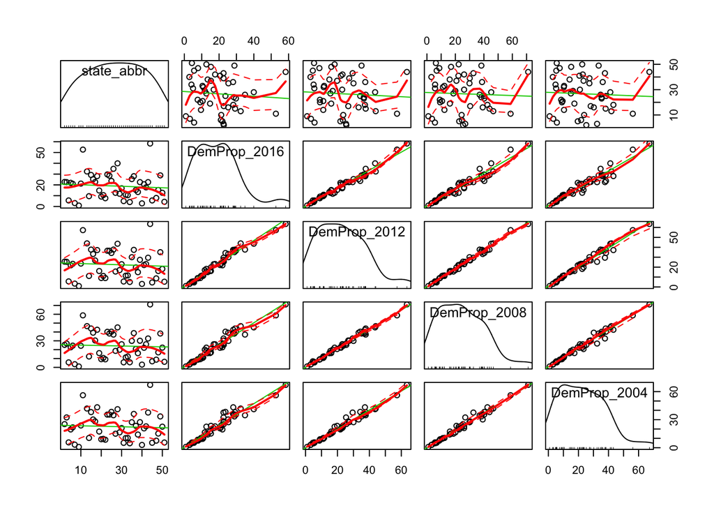

```r
library(ggplot2)
library(car)
library(gridExtra)

#scatterplot matrix to compare the distribution of votes in every election. They should be relatively similar across elections when looked at by party.
scatterplotMatrix(df.plot.Dem)
```

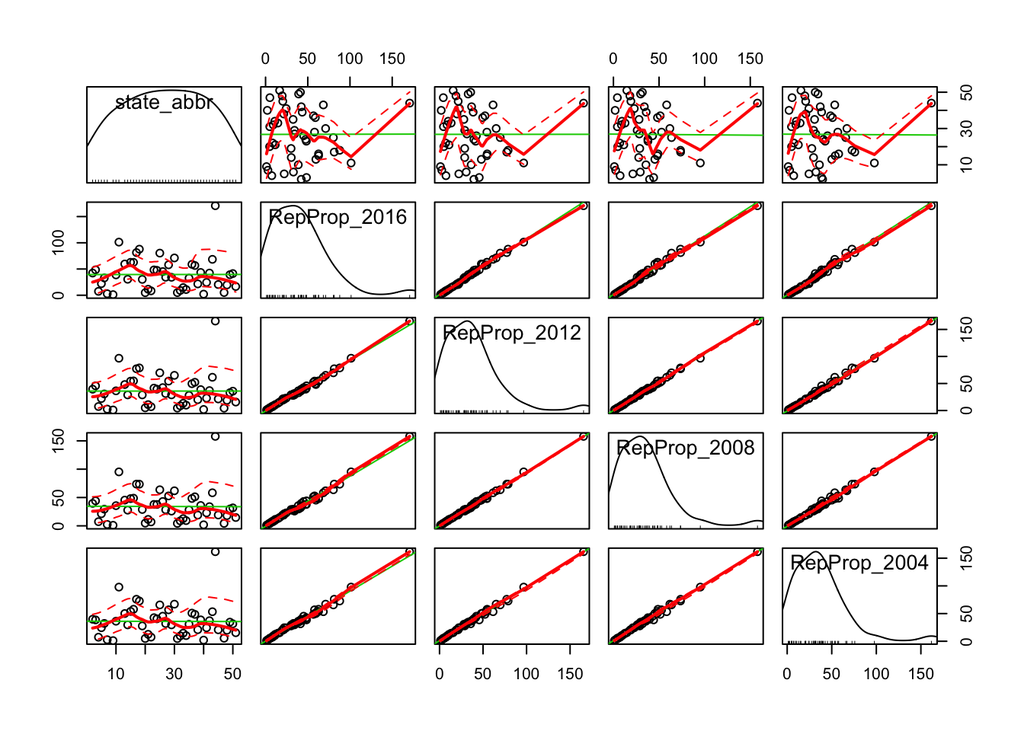

```r
scatterplotMatrix(df.plot.Rep)
```

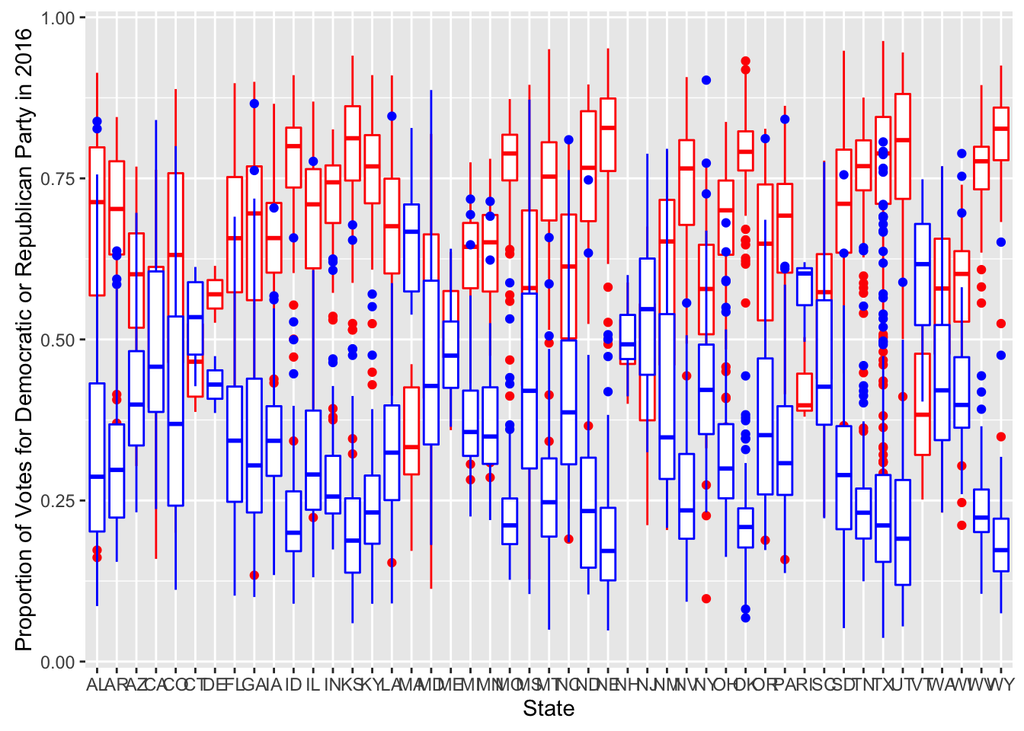

```r
#no large deviations, distributions are fairly similar across years

plot.2016 =
  ggplot(data = Election_Result_County) +
  geom_boxplot(mapping = aes(x = state_abbr, y = RepProp_2016), colour = "red") +
  geom_boxplot(mapping = aes(x = state_abbr, y = DemProp_2016), colour = "blue") +
  scale_x_discrete("State") +
  scale_y_continuous("Proportion of Votes for Democratic or Republican Party in 2016")

plot.2012 =
  ggplot(data = Election_Result_County) +
  geom_boxplot(mapping = aes(x = state_abbr, y = RepProp_2012), colour = "red") +
  geom_boxplot(mapping = aes(x = state_abbr, y = DemProp_2012), colour = "blue") +
  scale_x_discrete("State") +
  scale_y_continuous("Proportion of Votes for Democratic or Republican Party in 2012")

plot.2008 =
  ggplot(data = Election_Result_County) +
  geom_boxplot(mapping = aes(x = state_abbr, y = RepProp_2008), colour = "red") +
  geom_boxplot(mapping = aes(x = state_abbr, y = DemProp_2008), colour = "blue") +
  scale_x_discrete("State") +
  scale_y_continuous("Proportion of Votes for Democratic or Republican Party in 2008")

plot.2004 =
  ggplot(data = Election_Result_County) +
  geom_boxplot(mapping = aes(x = state_abbr, y = RepProp_2004), colour = "red") +
  geom_boxplot(mapping = aes(x = state_abbr, y = DemProp_2004), colour = "blue") +
  scale_x_discrete("State") +
  scale_y_continuous("Proportion of Votes for Democratic or Republican Party in 2004")

quartz()
plot.2016
```

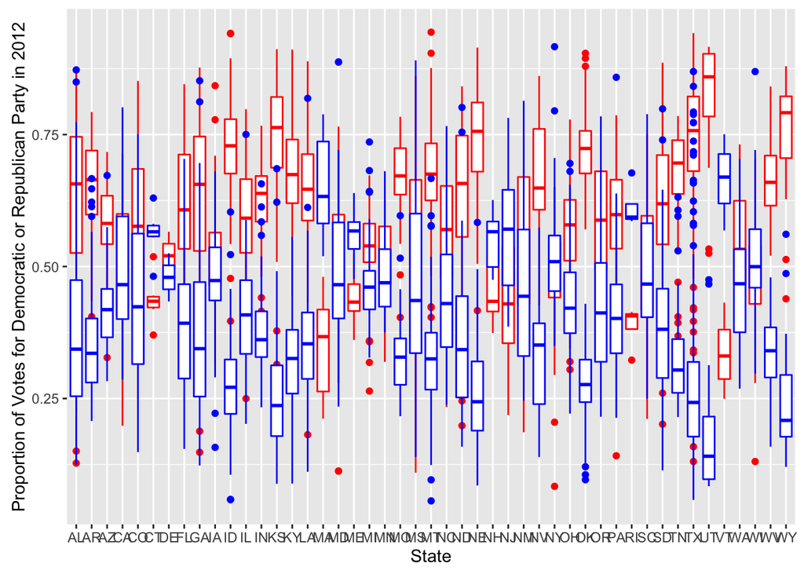

```r
plot.2012
```

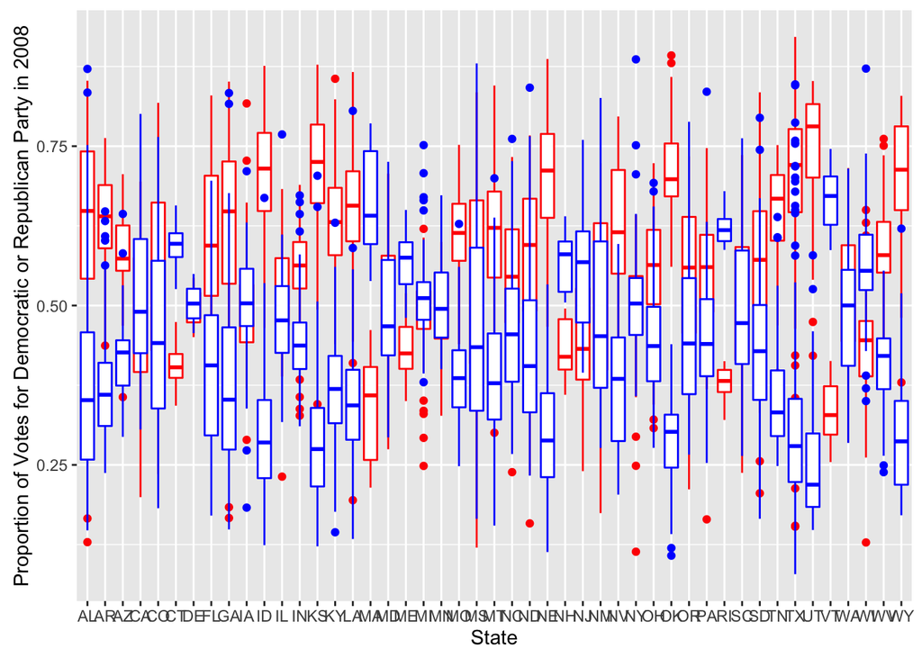

```r
plot.2008
```

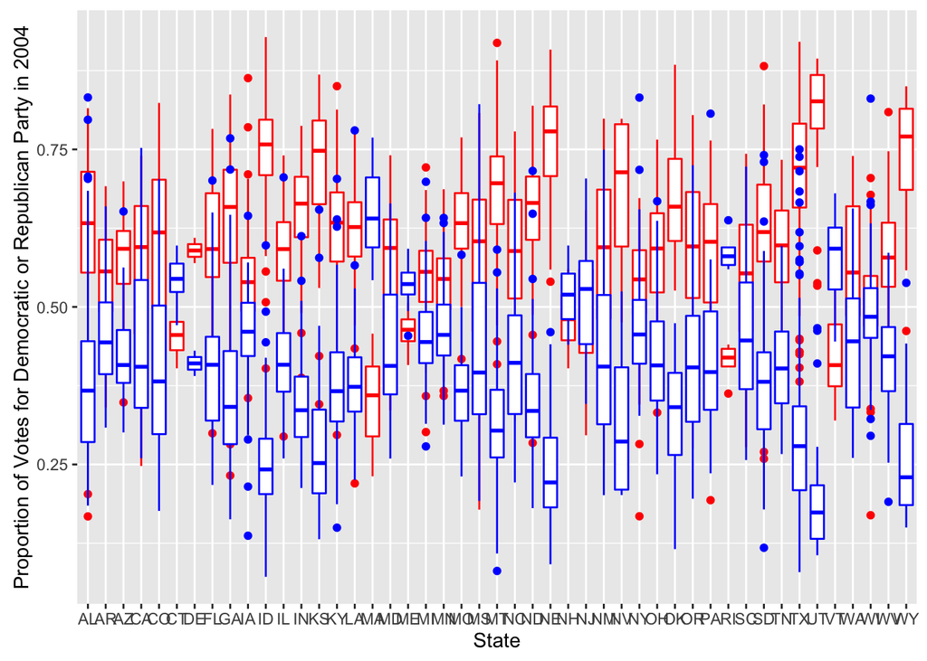

```r
plot.2004
```